# Notebook

[Sebastian Raschka](http://sebastianraschka.com)

- [Open in IPython nbviewer](http://nbviewer.ipython.org/github/rasbt/One-Python-benchmark-per-day/blob/master/ipython_nbs/day15_array_indexing_numpy.ipynb?create=1)
- [Link to this IPython notebook on Github](https://github.com/rasbt/One-Python-benchmark-per-day/blob/master/ipython_nbs/day15_array_indexing_numpy.ipynb)
- [Link to the GitHub Repository One-Python-benchmark-per-day](https://github.com/rasbt/One-Python-benchmark-per-day)

```python
import time
print('Last updated: %s' %time.strftime('%d/%m/%Y'))
```

```
Last updated: 24/06/2014
```

I would be happy to hear your comments and suggestions.  
Please feel free to drop me a note via [twitter](https://twitter.com/rasbt), , or [google+](https://plus.google.com/+SebastianRaschka).

# Day 15 - One Python Benchmark per Day

## Array indexing in NumPy: Extracting rows and columns

There are multiple ways in NumPy to extract particular rows or columns of interest from a NumPy array.

For example, given a 3x3-dimensional matrix **A** as shown below,

```python
import numpy as np
A = np.array([[1,2,3],[4,5,6], [7,8,9]])
print(A)
```

```
[[1 2 3]
 [4 5 6]
 [7 8 9]]
```

we now want to extract the first and the last column. The most intuitive way would probably be by direct indexing:

```python
print(A[:,[0,-1]])
```

```
[[1 3]
 [4 6]
 [7 9]]
```

But alternatively, we could also have used the [`numpy.take`](http://docs.scipy.org/doc/numpy/reference/generated/numpy.take.html) function here:

```python
print(np.take(A, indices=[0,-1], axis=1))
```

```
[[1 3]
 [4 6]
 [7 9]]
```

Equivalently, if we wanted to extract the first and last row:

```python
print(A[[0,-1],:])
```

```
[[1 2 3]
 [7 8 9]]
```

```python
print(np.take(A, indices=[0,-1], axis=0))
```

```
[[1 2 3]
 [7 8 9]]
```

Both approaches **`return`** a new array object, not just a view/reference to an existing array, which will be demonstrated in the following example:

```python
print('A before:\n', A)

B = A[[0,-1],:]
B[0,0] = 100


C = np.take(A, indices=[0,-1], axis=0)
C[0,0] = 150

print('\nB:\n', B)
print('\nC:\n', C)

print('\nA after:\n', A)
```

```
A before:
 [[1 2 3]
 [4 5 6]
 [7 8 9]]

B:
 [[100   2   3]
 [  7   8   9]]

C:
 [[150   2   3]
 [  7   8   9]]

A after:
 [[1 2 3]
 [4 5 6]
 [7 8 9]]
```

**Note**

`C = np.take(A, indices=[0,-1], axis=0)`  
is equivalent to  
`np.take(A, indices=[0,-1], axis=0, out=C)`  
However, the former approach is the slightly faster one:

```python
%timeit C = np.take(A, indices=[0,-1], axis=0)
%timeit np.take(A, indices=[0,-1], axis=0, out=C)
```

```
100000 loops, best of 3: 3.79 µs per loop
100000 loops, best of 3: 5.47 µs per loop
```

# `timeit` benchmarks

[back to top]

In the following benchmark, we will see how fast the two approaches are in returning the first column/row, a random column/row, and the last column/row of 2-dimensional arrays (in terms of their axes) consisting NxN elements.

```python
import timeit
from numpy import take as np_take

orders_n = [10**i for i in range(1, 5)]

idx_slice_col, idx_slice_row, np_take_col, np_take_row = [], [], [], []

for n in orders_n:

    rand_idx = np.random.randint(n)
    A = np.random.randn(n, n)
    idx_slice_col.append(min(timeit.Timer('A[:, [0, rand_idx, -1]]',
            'from __main__ import A, rand_idx').repeat(repeat=3, number=1)))
    np_take_col.append(min(timeit.Timer('np_take(A, indices=[0, rand_idx, -1], axis=1)',
            'from __main__ import A, rand_idx, np_take').repeat(repeat=3, number=1)))
    idx_slice_row.append(min(timeit.Timer('A[[0, rand_idx, -1], :]',
            'from __main__ import A, rand_idx').repeat(repeat=3, number=1)))
    np_take_row.append(min(timeit.Timer('np_take(A, indices=[0, rand_idx, -1], axis=0)',
            'from __main__ import A, rand_idx, np_take').repeat(repeat=3, number=1)))
```

## Preparing to plot the results

[back to top]

```python
import platform
import multiprocessing

def print_sysinfo():

    print('\nPython version  :', platform.python_version())
    print('compiler        :', platform.python_compiler())
    print('Numpy version   :', np.__version__)

    print('\nsystem     :', platform.system())
    print('release    :', platform.release())
    print('machine    :', platform.machine())
    print('processor  :', platform.processor())
    print('CPU count  :', multiprocessing.cpu_count())
    print('interpreter:', platform.architecture()[0])
    print('\n\n')
```

```python
%matplotlib inline
```

```python
import matplotlib.pyplot as plt

def plot():

    f, ax = plt.subplots(1, 2, figsize=(15,5))

    ax[0].plot(orders_n, idx_slice_col, alpha=0.4, lw=3, marker='o',
               label='Classic indexing\nA[:, [0, rand_idx, -1]]')
    ax[0].plot(orders_n, np_take_col, alpha=0.4, lw=3, marker='o',
               label='NumPy.take\nnp.take(A, indices=[0, rand_idx, -1], axis=1)')
    ax[0].set_title('Getting columns from a NumPy array')

    ax[1].plot(orders_n, idx_slice_row, alpha=0.4, lw=3, marker='o',
               label='Classic indexing\nA[[0, rand_idx, -1], :]')
    ax[1].plot(orders_n, np_take_row, alpha=0.4, lw=3, marker='o',
               label='NumPy.take\nnp_take(A, indices=[0, rand_idx, -1], axis=0)')
    ax[1].set_title('Getting rows from a NumPy array')

    for x in ax:
        x.legend(loc='upper left')
        x.set_ylabel('time in seconds')
        x.set_xlabel('NumPy array size')

    plt.tight_layout()
    plt.show()
```

# Results

[back to top]

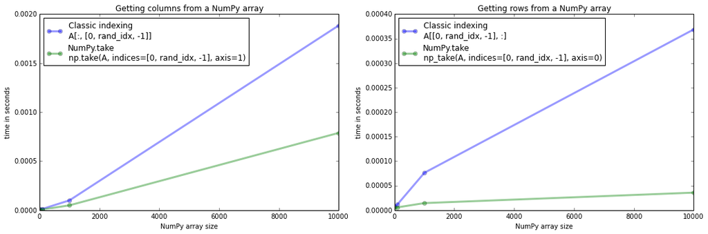

```
Python version  : 3.4.1
compiler        : GCC 4.2.1 (Apple Inc. build 5577)
Numpy version   : 1.8.1

system     : Darwin
release    : 13.2.0
machine    : x86_64
processor  : i386
CPU count  : 4
interpreter: 64bit
```

```python
plot()
print_sysinfo()
```